# Wprowadzenie do R

A. M. Machno

28 września 2015

## Referencje

R. Peng, R Programming [link](https://leanpub.com/rprogramming)

## Kalkulator

Środowisko R można wykorzystac do właściwie dowolnych obliczeń arytmetycznych na liczbach. To co jest wyświetlane w szarej ramce wpisane należy wpisać do konsoli i po wciśnieciu *enter* otrzymamy to co jest w białej ramce (po ##).

```r
1+15
```

```
## [1] 16
```

```r
4/2
```

```
## [1] 2
```

```r
6^3
```

```
## [1] 216
```

```r
625^(.5)
```

```
## [1] 25
```

```r
(1+3)/(2+3^2)
```

```
## [1] 0.3636364
```

## Funkcje

Możemy korzystać z ogromnej ilości funkcji wbudowanych w R oraz tworzyć własne. Funkcję wywołujemy wpisując jej nazwę oraz argumenty w nawiasie okrągłym.

-pierwiastek:

```r
sqrt(64)
```

```
## [1] 8
```

-funkcja eksponencjalna

```r
exp(2)
```

```
## [1] 7.389056
```

Aby dowiedzieć się więcej na temat danej funkcji wpisujemy `?nazwa_funkcji`. Niektóre funkcje mają więcej argumentów, np. funkcja licząca logarytm (`log`) ma dwa argumenty (liczbę, której logarytm chcemy policzy.c oraz podstawę logarytmu). W takiej sytuacji musimy musimy podac dwa argumenty.

liczymy $log_2 (16)$:

```r
log(16, 2)
```

```
## [1] 4
```

Spoglodając do opisu funkcji `log` możemy dowiedzieć się, że liczba logarytmowana to argument `x`, a podstawa to argument `base`. Wywołując funkcję możemy odwołać się do tych nazw nie pamietając o kolejności argumentów.

```r
log(x=27, base=3)
```

```
## [1] 3
```

```r
log(base=3, x=27)
```

```
## [1] 3
```

Niektóre agumenty mają wartości domyślne (właściwie to jest bardzo częsty przypadek). W przypadku logarytmu, argument `base` ma wartość domyślną równą *e*. Zatem jeżeli chcemy policzyć logarytm naturalny nie musimy wpisywać podstawy.

```r
log(2)
```

```
## [1] 0.6931472
```

```r
log(x=12)
```

```
## [1] 2.484907
```

Jednak jeżeli funkcja nie ma wartości domyślnej do argumentu, nie wpisując wartości otrzymamy błąd. Np. `log(base=5)`.

Wiele funkcji nie ma argumentów, lub wszystkie jej argumenty mają wartości domyślne, i tak możemy dowiedzieć się w jakim katalogu pracujemy wpisując `getwd()` lub wyświetlając wszystkie obiekty, które przechowujemy w naszym środowisku `ls()`.

```r
getwd()
```

```
## [1] "C:/Users/Artur/Dropbox/AGH/dydaktyka/statystyka ZiP/2015-2016/R"
```

```r
ls()
```

```
## character(0)
```

Jeszcze nie stworzyliśmy ani nie wczytaliśmy nic do naszego środowiska, dlatego wyświetla pustą listę.

## Wektory

Podstawowymi wartościami w R są wektory. Podstawową funkcją, która tworzy wektor jest `c()`.

```r
c(1,3,11,-1,.3)
```

```
## [1]  1.0  3.0 11.0 -1.0  0.3
```

Pracując na wektorach, przeważnie chcemy przypisać jakiejś zmiennej wartości. Stórzmy zatem dwa 5-elementowe wektory `x` i `y`. Do przypisywania wartości służy operator `<-` (lub `->`).

```r
x<-c(2, -1, 3, 1.5, -.5)
y<-c(1, 2, 3, -1, -5)
```

Tym razem po wpisaniu komend do consoli nie dostaliśmy żadnej odpowiedzi, ale możemy odwołać sie do zmiennych.

```r
x; y
```

```
## [1]  2.0 -1.0  3.0  1.5 -0.5
```

```
## [1]  1  2  3 -1 -5
```

Wszystkie podstawowe funkcje liczbowe możemy stosować do wektorów. Działania są wykonywane dla pierwszych elementów wektorów i wartość jest pierwszym elementem wektora wyniku itd. Innymi słowy jest działanie wyraz po wyrazie.

```r
exp(x)
```

```
## [1]  7.3890561  0.3678794 20.0855369  4.4816891  0.6065307
```

```r
x+y
```

```
## [1]  3.0  1.0  6.0  0.5 -5.5
```

```r
x/y
```

```
## [1]  2.0 -0.5  1.0 -1.5  0.1
```

```r
x^y
```

```
## [1]   2.0000000   1.0000000  27.0000000   0.6666667 -32.0000000
```

Wiele funkcji jako argument (lub kilka argumentów) ma wektor. Podstawowe to np. suma `sum()`, średnia arytmetyczna `mean()`.

```r
sum(x); sum(y)
```

```
## [1] 5
```

```
## [1] 0
```

```r
mean(x); mean(y)
```

```
## [1] 1
```

```
## [1] 0
```

Dzieki temu bardzo szybko możemy policzyć np. wariancję `x`:

```r
mean((x-mean(x))^2); mean((y-mean(y))^2)
```

```
## [1] 2.3
```

```
## [1] 8
```

```r
sum((x-mean(x))^2)/length(x); sum((y-mean(y))^2)/length(y)
```

```
## [1] 2.3
```

```
## [1] 8
```

```r
sum((x-mean(x))^2)/(length(x)-1); sum((y-mean(y))^2)/(length(y)-1)
```

```
## [1] 2.875
```

```
## [1] 10
```

Oczywiście jest też funckja `var()`, która oblicza wariancję dla wartości z wektora.

```r
var(x); var(y)
```

```
## [1] 2.875
```

```
## [1] 10
```

## Obiekty podstawowe

W R rozróżniamy 6 podstawowych typów obiektów (które przeważnie są elementami wektora):

1. character (napis). Wpisujemy w cudzysłowiu, np. `"to jest napis"`.
2. complex (liczba zespolona). Wpisujemy cześć rzeczywistą plus część urojoną *i*, bez znaku mnożenia, np. `1+2i`.
3. numeric (liczba rzeczywista). Po prosu wpisujemy liczbę, może byc poprzedzona minusem aby była ujemna, część dziesiętna po **kropce**.
4. integer (liczba naturalna). Wpisujemy liczbę i *L*, np. `2L`.
5. factor (zmienna kategoryczna).
6. logical (wartość logiczna TRUE/FALSE). Wpsujemy `TRUE` lub `FALSE`, przekształcane są w odpowiednio 1 i 0.

Rozróżnienie jest ważne, dlatego, że wektory muszą być jednorodne ze względu na obiekty (wszystkie elementy wektora muszą mieć ten sam typ). Typy wypisałem w nieprzypadkowej kolejności, zamiana wektora, który ma wyższy typ bezproblemowo zamienimy na tym niższy, odwrotna operacja przeważnie nie jest możliwa. Jezeli spróbujemy stworzyć wektor niejednorodny, R wybierze obiekt najniższego rzędu w tym wektorze i pozostałe lementy przekształci w ten tym.

```r
mix_vect_1<-c(1L, TRUE, 2+3i)
typeof(mix_vect_1); mix_vect_1
```

```
## [1] "complex"
```

```
## [1] 1+0i 1+0i 2+3i
```

```r
mix_vect_2<-c(1,2, 'napis')
typeof(mix_vect_2); mix_vect_2
```

```
## [1] "character"
```

```
## [1] "1"     "2"     "napis"
```

Z punktu widzenia tego kursu najważniejsze są wektory numeryczne i logiczne (okazjonalnie będziemy korzystać z napisów).

## Wartości specjalne

W wyniku niektórych operacji możemy otrzymac nieksończoność `Inf`. Nieskończoność możemy też używać do obliczeń.

```r
1/0
```

```
## [1] Inf
```

```r
.99^Inf
```

```
## [1] 0
```

Jednak niektórych działań nie da się wykonać i otrzymamy liczbe nioznaczoną.

```r
0/0
```

```
## [1] NaN
```

```r
(-1)^.1
```

```
## [1] NaN
```

Jeżeli chcielibysmy przekształcić napis w liczbę, a napis nie będzie liczba otrzymamy również wartość nieoznaczoną:

```r
as.numeric(mix_vect_2)
```

```
## [1]  1  2 NA
```

Widzimy, że dwa pierwsze lementy przekształcono w liczny, a trzeci został zastąpiony przez `NA`. Różnicą między `NaN` i `NA` nie będziemy się zajmować i obie będziemy traktować jak wartości brakujące lub błędne w zalezności od kontekstu.

## Atrybuty

Wiele obiektów w R posiada atrybuty, w szczególności wektory. Przykładowe atrybuty to:

- names, dimnames (nazwa, nazwa wymiarów dla macierzy i innych wielowymiarowych obiektów).
- dim (wymiar).
- class (klasa).
- length (długość).

Wszystkie atrybuty danego obiektu możemy uzyskać dzięki funkcji `attributes()`.

Przypiszemy nazwy wartościom w wektorze `mix_vect_1`, odpowiadjące jego klasie.

```r
names(mix_vect_1)
```

[output not shown]

```r
names(mix_vect_1)<-c('integer', 'logical', 'complex')
names(mix_vect_1)
```

```
## [1] "integer" "logical" "complex"
```

```r
mix_vect_1
```

```
## integer logical complex
## 1+0i 1+0i 2+3i
```

## Podzbiory

Aby otrzymać konkretną współrzędna wektora odwołujemy sie do niego w nawiasie kwadratowym. Trzeci element wektora *x* to:

```r
x[3]
```

```
## [1] 3
```

Aby otrzymać wektor, składający się z wektora *x* bez jego trzeciego elementu poprzedzamy to znakiem minus:

```r
x[-3]
```

```
## [1]  2.0 -1.0  1.5 -0.5
```

Możemy odwołać się do wektora, składającego się z trzeciego i piątego elementu *x*:

```r
x[c(3,5)]
```

```
## [1]  3.0 -0.5
```

**Ważne**: odwołanie jest wektorem a nie ciągiem liczb!

## Operatory i warunkowanie logiczne

Podstawowe operatory logiczne to koninkcja `&`, alternatywa `|` i negacja `!`. W zastosowaniach najczęstsze waunki, które nas interesują to czy zachodzi równość `==`, nierówność `!=`, mniejszość `<`, niewiększość `<=`, większość `>` i niemniejszość `>=`.

Sprawdźmy czy 2 jest większe od 3:

```r
2>3
```

```
## [1] FALSE
```

Możemy w jednej komendzie sprawdzić, które elementy *x* są ujemne:

```r
x<0
```

```
## [1] FALSE  TRUE FALSE FALSE  TRUE
```

lub, które lementy *x* są niemnijesze niż odpowiednie elementy *y*:

```r
x>=y
```

```
## [1]  TRUE FALSE  TRUE  TRUE  TRUE
```

Dzięki wektorom logicznym, możemy otrzymać wszystkie dodatnie wartości z wektora *y*:

```r
y[y>0]
```

```
## [1] 1 2 3
```

Szczególnie wygodne i użyteczne jest używanie warunków logicznych do konstrukcji podzbiorów. Jakie wartości przyjmuje *x* jeżeli y jest dodatni?

```r
x[y>0]
```

```
## [1]  2 -1  3
```

## Statystyka Opisowa

Przykładowe statystyki opisowe, dla których są funkcje w podstawowym pakiecie R to:

- średnia `mean()`
- mediana `median()`
- odchylenie standardowe `sd()`
- odchylenie średnie `aad()`
- kwantyl (w szczególności kwartyle) `quantile`

Przykładowe statystyki opisowe, dla których nie ma funkcji w podstawowym pakiecie R to:

- dominanta
- skośność
- kurtoza

## Przykłady

Wczyutajmy dane `mtcars`, które są dostępny w podstawowym pakiecie R.

```r
data(mtcars)
str(mtcars)
```

```
## 'data.frame':    32 obs. of  11 variables:
##  $ mpg : num  21 21 22.8 21.4 18.7 18.1 14.3 24.4 22.8 19.2 ...
##  $ cyl : num  6 6 4 6 8 6 8 4 4 6 ...
##  $ disp: num  160 160 108 258 360 ...
##  $ hp  : num  110 110 93 110 175 105 245 62 95 123 ...
##  $ drat: num  3.9 3.9 3.85 3.08 3.15 2.76 3.21 3.69 3.92 3.92 ...
##  $ wt  : num  2.62 2.88 2.32 3.21 3.44 ...
##  $ qsec: num  16.5 17 18.6 19.4 17 ...
##  $ vs  : num  0 0 1 1 0 1 0 1 1 1 ...
##  $ am  : num  1 1 1 0 0 0 0 0 0 0 ...
##  $ gear: num  4 4 4 3 3 3 3 4 4 4 ...
##  $ carb: num  4 4 1 1 2 1 4 2 2 4 ...
```

Jest to ramka danych (*data.frame*) składająca się z 32 obserwacji i 11 wartości dla każdej z nich. Są to dane techniczne 32 modeli samochodów.

Ramke danych możemy traktować jak dwuwymiarową tablicę i odwoływać się do elementów przez nawias kwadratowy. Gdzie na pierwszej współrzędnej podajemy które wiersze mają być wyswietlone, a na drugiej, które kolumny. Po pozostawieniu pustego wymiaru, wszystkie lementy zostana wyswietlone.

```r
mtcars[1,c(1,2)]
```

```
##           mpg cyl
## Mazda RX4  21   6
```

```r
mtcars[,3]
```

```
##  [1] 160.0 160.0 108.0 258.0 360.0 225.0 360.0 146.7 140.8 167.6 167.6
## [12] 275.8 275.8 275.8 472.0 460.0 440.0  78.7  75.7  71.1 120.1 318.0
## [23] 304.0 350.0 400.0  79.0 120.3  95.1 351.0 145.0 301.0 121.0
```

Możemy odwołać sie do zmiennej w danych przez jej nazwę iznak dolara:

```r
#liczba cylindrów w kolejnych samochodach
mtcars$cyl
```

```
##  [1] 6 6 4 6 8 6 8 4 4 6 6 8 8 8 8 8 8 4 4 4 4 8 8 8 8 4 4 4 8 6 8 4
```

Policzmy średnią masę samochodów z bazy `mtcars`

```r
mean(mtcars$wt)
```

```
## [1] 3.21725
```

Policzmy teraz średnią masę dla samochodów z 8 cylindrami:

```r
#dla jasności wprowadzamy nowe wektory odpowiadające wadze i ilości cylindrów
weight<-mtcars$wt
cylinders<-mtcars$cyl
mean(weight[cylinders==8])
```

```
## [1] 3.999214
```

Na histogramie objętości silników, widzimy, że dane są lekko niesymetryczne:

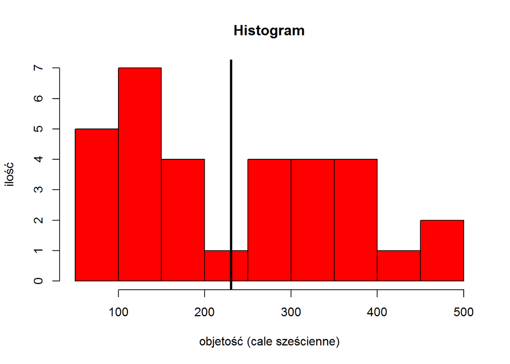

```r
hist(mtcars$disp, main="Histogram", col=2, xlab="objetość (cale sześcienne)", ylab="ilość")
abline(v=mean(mtcars$disp), lw=3)
```

Policzmy zatem skośność:

```r
#dla wygody tworzymy nową zmienną
disp<-mtcars$disp

#liczmy średnią
disp.mean<-mean(disp)

#i odchylenia od średniej
disp.dev<-disp-disp.mean

#trzecia potęga odchyleń i srednia
disp.dev.3<-disp.dev^3

#to jest trzeci moment centralny
disp.dev.3.mean<-mean(disp.dev.3)

#skośność
  disp.dev.3.mean/sd(disp)^3
```

```
## [1] 0.381657
```